# Walkthrough

Laélie Huet

2025-11-25

## Introduction

This age-class model was built to reproduce a biologically realistic Ballan wrasse population.

The Ballan wrasse is a protogynous hermaphroditic fish species that has a haremic social system, with one male for multiple females. All individuals are born females and join a harem once they attain reproductive age. It appears that when the male of the harem dies, the oldest or biggest females are the ones to transition to become male. Because of this particularity, the population also presents a skewed sex ratio, with somewhere around 20% of the population being male.

this model was adapted to account for these particularities, using published equations and data.

## Adaptations

### Growth

Because only the biggest females transition to become males, there are two different Von Bertalanffy curves for males and females. The parameters for these were taken from Leclerq et al. (2014). Here are the two curves:

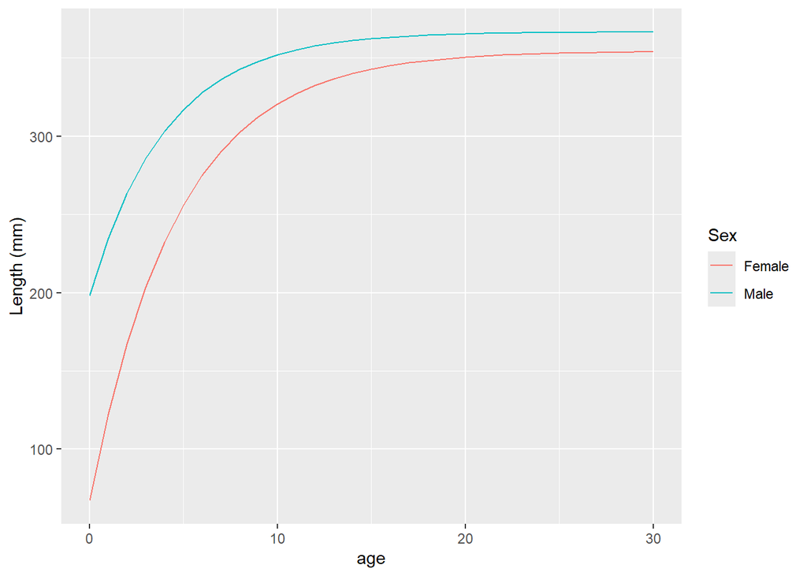

While the parameters for the body allometry do not change between males and females, because the VB curve does, the output at age is also different:

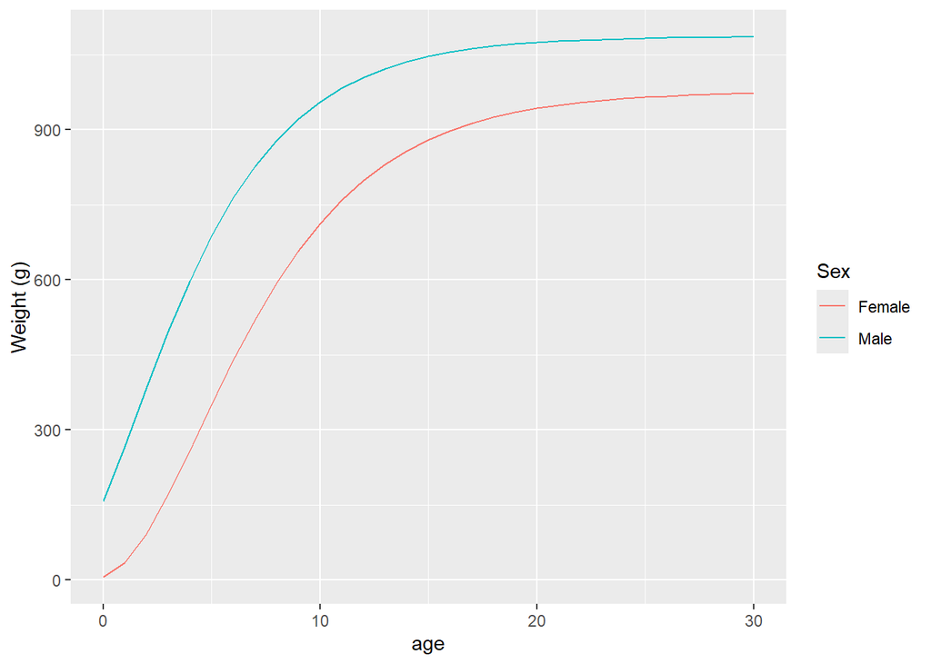

Note: Here it appears that males are born already quite heavy, but since no individuals are directly born as males, this is actually fine.

Because of these differences in length and weight, all following equations that use either of those variables were calculated separately for males and females.

### Sex change

As sex change seems to depend on sex ratio and size for the species, I decided to go with an equation that uses the relative size rule (difference from the average size) to dictate sex change, so that once an individual is a certain size above average, it becomes male. This equation was taken from Alonzo & Mangel (2005):

$P_c(L)=\frac{1}{1+exp(-b(L-(L_i+\Delta L_c)))}$,

Where $L_i$ is the average size in the population, $\Delta L_c$ is the difference above the mean at which the probability of undergoing sex change equals 0.5, and $b$ is a shape parameter. Then, individual count equations were modified to account for newly transitioned individuals:

$N_{F,a+1,t+1}=(N_{F,a,t}-N_{F,a,t}*P_c(L_{F,a}))e^{-Z_a}$ and $N_{M,a+1,t+1}=(N_{M,a,t}+N_{F,a,t}*P_c(L_{F,a}))e^{-Z_a}$,

So that the number of females at age+1 the next year equals the number of females at age this year minus the transitioning females, and the number of males at age+1 next year equals the number of males at age this year plus the transitioned males. for both equations, mortality is accounted for after sex change.

Once implemented in a stable population, this sex change equation makes the age and sex specific individual counts look like this:

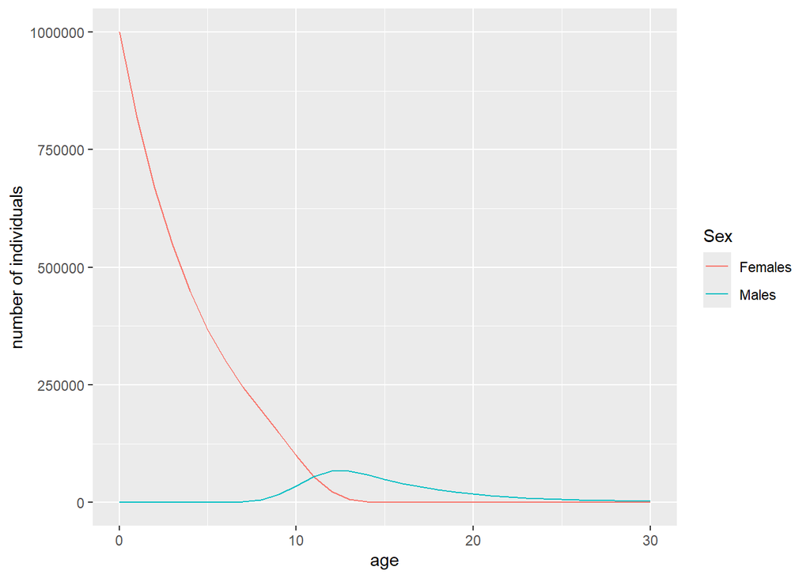

Which allows for a male ratio of

```
## [1] 0.2837438
```

Which is in the upper realistic range for this species.

### Reproduction

Because this species is protogynous, high fishing recruitment could lead to make depletion, leading to a population crash, even though the number of individuals in the population stays elevated. Therefore, the recruitment calculation needs to account for potential male depletion, which a classical recruitment function based on spawner stock like Beverton-Holt or Ricker cannot do.

Therefore, I decided to go with a recruitment function modified from Beverton-Holt and based on fertilized eggs counts, from Brooks et al. (2008):

$R(\psi)=\frac{4hR_0\psi}{R_0\phi _0(1-h)+(5h-1)\psi}$

Where $\phi_0$ is the number of fertilized eggs per recruit in the unfished stable population, $R_0$ is the unfished recruitment, which can also be interpreted as the maximum population size, and $h$ is a measure of steepness.

Using fertilized egg counts allows to take into account the fertilization rate, which will be dependent on the difference between the current male ratio and the male ratio in a stable population. For more detailed information on the equations used for recruitment, please refer to the original report.

Here is the resulting population growth when we start the simulation, followed by population maintenance, with forced recruitment equal to R0 during the burn-in (aka, the initialization period needed to reach a stable population).

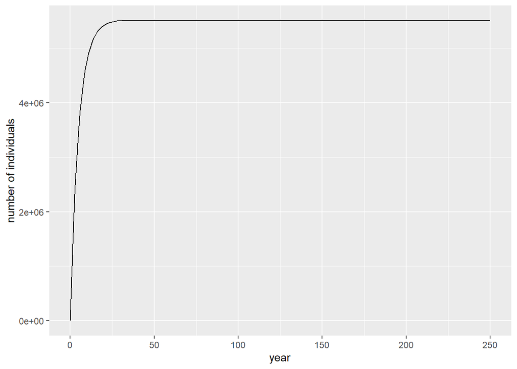

**Note:** the burn-in length was originally set this high because the original model was a colonization model, so it took longer to stabilize. I then realised it was better to start the model without a realistic colonization event. The burn-in period was not adjusted after this, but I expect the impact to be minimal on the results.

### Fishing recuitment, catch and yield

Because we have males and females of different sizes, fishing recruitment, catch, yield, as well as mortality has to be calculated separately for females and males before being summed up. For details on the equations see the original report.

## Parametrization

To make the model function, I needed to find data for Von Bertalanffy, body allometry, and fecundity equations. These were obtained from two studies of Ballan wrasse conducted by Leclerq et al. (2014) and Villegas-Rios et al. (2014). Other parameters were either estimated through iteration or assumed:

```
##     symbol      value
## 1       N0  3.000e+01
## 2        M  2.000e-01
## 3    LinfF  3.544e+02
## 4       KF  2.140e-01
## 5      t0F -9.800e-01
## 6    LinfM  3.666e+02
## 7       KM  2.440e-01
## 8      t0M -3.190e+00
## 9   alpha0  9.310e-03
## 10  alpha1  3.146e+00
## 11       b  1.000e-01
## 12 deltaLC  1.250e+02
## 13   beta0  1.170e-01
## 14   beta1  9.563e+00
```

[output cut: 23 more lines]

## Simulation

As this model was constructed to evaluate the fishing size limits implemented in Europe for this species, these were used for simulations and compared across a range of fishing rates F. Here are the fishing size limits (Pritchard et al. 2025):

```
##                        location Lmin Lmax
## 1 England Devon and Severn IFCA  180  260
## 2                        Norway  220  280
## 3                      Scotland  120  240
## 4                        Sweden  150  300
## 5                   theoretical  290  350
```

## Results

### Population size

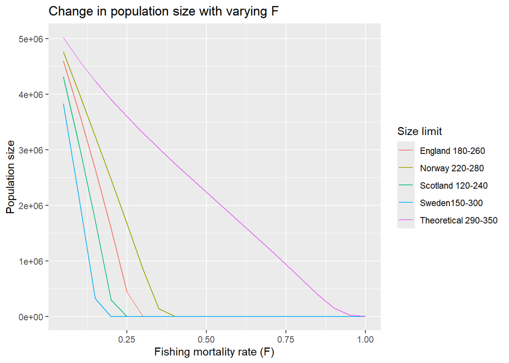

Under the current size limits, it appears that the Ballan wrasse populations are very sensitive, and already crash at low fishing mortality rates. While the chosen theoretical fishing sizes do not prevent a population crash at fishing rates superior to 0.9, it allows for more resilience that current fishing sizes.

### Catch

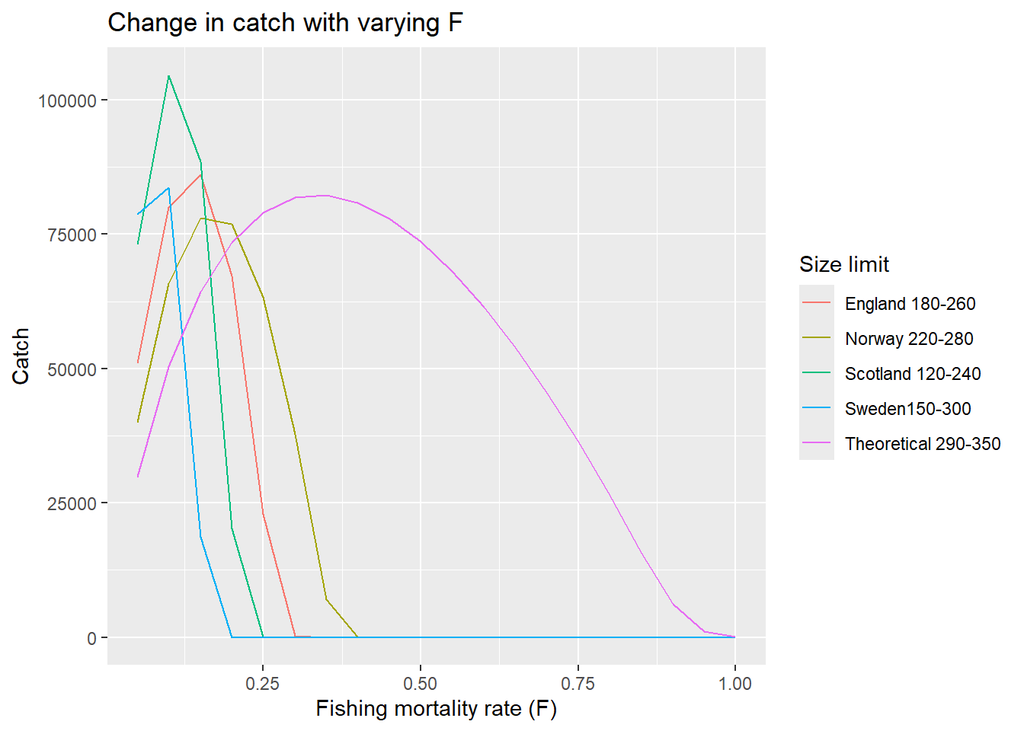

The maximum catch is similar between all size limits, however, the maximum catch is reached at higher fishing mortality rate under the theoretical size limit. While the maximum catches with current size limits are similar to the one under the theoretical size limit, the peaks happen at very low fishing mortality rate and crash earlier.

### Yield

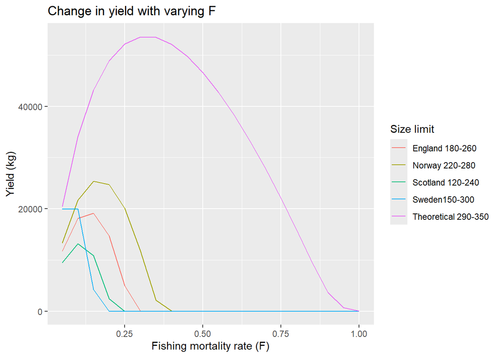

Because a higher theoretical size limit allows to catch bigger fish, the maximum yield of the theoretical size limit is much higher than the yield under current size limits.

## Discussion

It appears that under current size limits, Ballan wrasse populations would likely crash in the long term, even under light fishing mortality rates. While higher size limits protects populations a bit more, it still does not fully protect populations at moderate fishing rates. That might be attributed to the protogynous and haremic nature of the species, making males more scarce and more vulnerable to fishing.

While higher fishing size limits would allow for more protection of the fished populations, it might not align with the purpose of Ballan wrasses on the market, as this species is mainly fished to be used against salmon lice in salmon fisheries.

## Model limits and differences from original

**Differences between models**

Compared to the original model, this model used the correct version of the recruitment function, using fertilized eggs per recruit, instead of fertilized eggs per females. It also uses a fixed phi0 instead of a phi0 recalculated every year. This specific change could be the cause of the difference in sustainability observed with the theoretical size limit between the two models.

**Model limits**

Like the previous model, this model uses age-classes and doesn’t have a maturity ogive. The use of age-classes and of a maturity ogive could allow for the model to be more realistic, therefore allowing more trusted results than those obtained at this stage.

**For the references, please see the original report.**